## [Projet Machine Learning 2]-[4DS2]

[figure not shown]

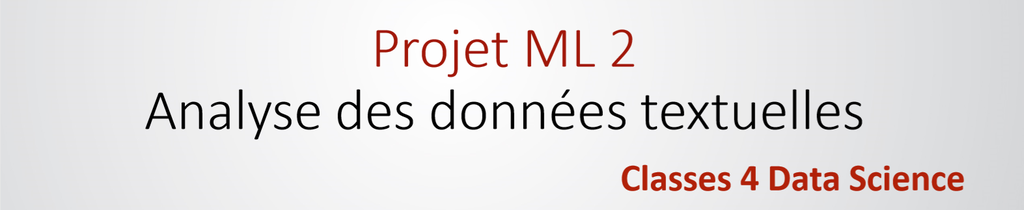

[figure not shown]

## **Table des matières :**

- Introduction
- Motivation :
- Notre cas :
- Notre Objectif :
- Phase 1 : Agrégation et traitement(nettoyage) des offres d’emploi provenant de sites de recrutement, réseaux sociaux et d’autres sources notamment :  
  — des fichiers sous forme : **PDF & WORD**  
  — à partir du site : **GLASSDOR**  
  — à partir du site : **INDEED**  
  — à partir du site : **TALENTS**  
  — à partir du site : **CADRE D'EMPLOI**
- Phase 2 : Classification et Labélisation :  
  — *** Titre | Job title ***  
  — *** Recruteur | comapny name ***  
  — *** Type du contrat | contract type ***  
  — *** Ville | Location ***  
  — *** Description | Description ***
- Phase 3 : Réalisation du dictionnaire sémantique et affichage de l'Output Intermédiaire :
- Phase 4 : création d’un mini-moteur de recherche sémantique à partir du texte () :

**===> Présentation ppt**

## **Introduction :**

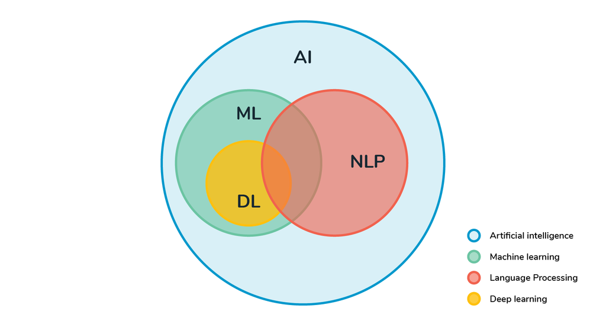

- Natural Language Processing (NLP) autrement appelé en français “Traitement automatique du langage naturel” est une branche très importante du Machine Learning et donc de l'intelligence artificielle. Le NLP est la capacité d'un programme à comprendre le langage humain
- Il est important de comprendre que pour avoir un algorithme qui marche avec du NLP, il faut un grand nombre de données afin d’éviter les biais. Il y a trois types d’ensembles de données :
- - Ensemble de données entraînées (training set)
- - Ensemble de données validées (validation set)
- - Ensemble de données testées (testing set)
- On forme avec l’aide du “set d’entraînement”, on ajuste les paramètres à l’aide du “set de validation”, pour ensuite tester les performances.

## **Téléchargement des bibliotéques nécessaires :**

```python
import PyPDF2
import docx

import pandas as pd
import numpy as np
import matplotlib.pyplot as plt

import unicodedata
#import os
#import pickle
import random

import spacy
from spacy.matcher import PhraseMatcher
from spacy.lang.fr.stop_words import STOP_WORDS as en_stop
import nltk
import nltk.corpus
from nltk.corpus import stopwords
from nltk.tokenize import word_tokenize
from nltk.stem import PorterStemmer
import gensim
import gensim.corpora as corpora
from gensim.utils import lemmatize, simple_preprocess
from gensim.models import CoherenceModel
from textblob import TextBlob
from textblob import Word
import re


import json
from io import StringIO
import string
#nltk.download("all")


from sklearn.model_selection import train_test_split

import sklearn.feature_extraction.text as text

from sklearn.feature_extraction.text import CountVectorizer,TfidfVectorizer,HashingVectorizer
from sklearn.feature_extraction import DictVectorizer
from sklearn.linear_model import Perceptron
from sklearn.linear_model import SGDClassifier
from sklearn.linear_model import PassiveAggressiveClassifier

from sklearn import model_selection, preprocessing,linear_model, naive_bayes, metrics, svm , metrics
from sklearn.naive_bayes import MultinomialNB
from sklearn.linear_model import LogisticRegression
from sklearn.ensemble import RandomForestClassifier
from sklearn.svm import LinearSVC
from sklearn.model_selection import cross_val_score,train_test_split


from sklearn.metrics import confusion_matrix
#from sklearn.multiclass import OneVsRestClassifier

from sklearn.metrics import classification_report,accuracy_score

from imblearn.over_sampling import RandomOverSampler

from langdetect import detect

import itertools

seed = 42
```

# **Phase1 : Agrégation et traitement(nettoyage) des offres d’emploi provenant de sites de récrutement, réseaux sociaux et d’autres sources notamment**

## **étape1 : Importation et éxploration des données a partir des fichiers pdf et word :**

- Dans cette phase, nous nous sommes concentrés sur des fichiers word et pdf.
- créer des données d'entraînement annotées manuellement pour former le modèle.
- À cet effet, 50 offres d'emploi ont été téléchargés à partir plusieurs platefrom d'emplois en ligne.
- Dans une première étape, on a extrait mannuellement ces fichiers pdf les informations qui correspondent à chacuns des labels suivants

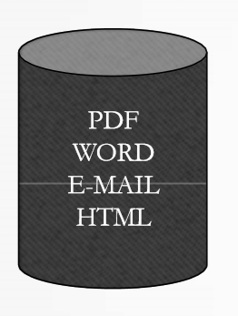

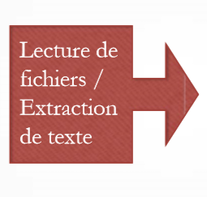

*- transformation des fichiers "pdf" en texte :*</i>

- Pour l'extraction des fichier pdf on a utilisé la bibliothéque **PyPDF2**, c'était la meilleur bibliothéque car elle permet de:

  -- Conserver l'encodage  
  -- Détecter les pages  
  -- Détecter les paragraphes et les sous paragraphes  
  -- Cette premiére fonction **pdf_to_txt** permet l'extraction de texte en chaine toute en citant le path comme entrée
- La fonction **allpdf** permet l'extraction de tous les pdfs sous un dossier en citant le nombre des pdfs comme entrée(en faisant le traitement de text necessaire : enlever les sauts de ligne et les majuscules ).

```python
def pdf_to_txt(path):
    f=open(path,"rb")
    pdf_reader=PyPDF2.PdfFileReader(f)
    text=""
    for i in range(pdf_reader.numPages):
        pageone=pdf_reader.getPage(i) # extraire le texte pour chaque page
        text=text+pageone.extractText()
    text.replace('\n',"") # éliminer les sauts de ligne
    return text
def allpdf(number):
    all_pdf=[]
    for i in range(number):
        text=pdf_to_txt(r"C:/Users/LEGION/Desktop/nlppp/data_pdf/Offre"+str(i+1)+".pdf")
        text=text.replace('\n',"") # éliminer les sauts de ligne
        text=text.lower() # rendre le texte en minuscule
        all_pdf.append(text)
    return all_pdf
```

```python
all_offres=allpdf(20)
```

```python
len(all_offres)
```

```
20
```

```python
all_offres;
```

*- transformation des fichiers "word" en texte :*</i>

- Le choix de la bibliothéque **docx** était pour les raisons suivantes:

  -- Préservation d'encodage  
  -- Lecture et détection des paragraphes
- La fonction **get_Text** prendre comme entrée le nom du fichier ou son path puis elle retourne une chaine de caractére de jointure des différents pargraphes
- La fonction **list_text** permet l'extraction de tous les documents word sous un dossier en citant le nombre des pdfs comme entrée(en faisant le traitement de text necessaire : enlever les sauts de ligne et les majuscules ).

```python
def get_Text(filename):
    doc = docx.Document(filename)
    fullText = []
    for para in doc.paragraphs:
        fullText.append(para.text)
    return ' '.join(fullText)
#fonction qui retourne tous les offres word
def list_text(count_files,list_text):
    for i in range(21,51):
        new_str=unicodedata.normalize("NFKD",get_Text(r"C:/Users/LEGION/Desktop/nlppp/data_word/offre"+str(i)+".docx"))
        new_str=new_str.lower()
        list_text.append(new_str)
    return list_text
```

```python
all_offres=list_text(30,all_offres)
len(all_offres)
```

```
50
```

```python
all_offres[49]
```

```
'job title:  data scientist; company name: amazon;  contract type: fixed price contract; location:washington ; description: advanced knowledge and expertise with data modelling skills. ability to distill informal customer requirements into problem definitions, dealing with ambiguity and competing ob…
```

- Séparation des differents champs textuels et les affectant à une liste (pour chaque offre) pour préparer la dataFrame avec laquelle on va travailler :

```python
v=[]
for j in range(0,50):
    p=list(all_offres[j].split(";"))
    v.append(p)
```

```python
v[49] # dernier élément
```

```
['job title:  data scientist',
 ' company name: amazon',
 '  contract type: fixed price contract',
 ' location:washington ',
 ' description: advanced knowledge and expertise with data modelling skills. ability to distill informal customer requirements into problem definitions, dealing with ambiguity and competing objectives. ability to manage and quantify improvement in customer experience or value for the business result…
```

- extraction du contenu de chaque partie de chaque offre :

```python
# first try :
w=[]
s=v[0][1] # offre 1 , element2 : company name
c=v[0][2] # offre 1 , element3 : contract type
n=s[s.find(":")+1:] # contenu element2 : company name
m=c[c.find(":")+1:] # contenu element3 : contract type
w.append(n)
w.append(m)
```

```python
w # liste de : -contenu element2 : company name -contenu element3 : contract type
```

```
[' pathrise recruiting partners', ' fixed price contract']
```

```python
r=[]
for i in range(len(v)):
    w=[]
    for j in range(len(v[i])):
        s=v[i][j] # récupération des parties de chaque offre
        n=s[s.find(":")+1:] # récupération du contenu de chaque partie de l'offre
        w.append(n)
    r.append(w)
```

```python
r[49]
```

```
['  data scientist',
 ' amazon',
 ' fixed price contract',
 'washington ',
 ' advanced knowledge and expertise with data modelling skills. ability to distill informal customer requirements into problem definitions, dealing with ambiguity and competing objectives. ability to manage and quantify improvement in customer experience or value for the business resulting from rese…
```

```python
data=pd.DataFrame(r,columns=['titre','recruteur','type_contrat','ville','descriptions'])
```

- Utilisation la méthode correct() du textblob pour tenter de corriger l'orthographe.

```python
#data["descriptions"].apply(lambda x: str(TextBlob(x).correct()))
```

```python
#data.to_excel("data.xlsx")
```

## **étape2 : web scrapping :**

- On a optez à elargir notre dataset via web scrapping des sites suivants:

[figure not shown]

[figure not shown]

[figure not shown]

[figure not shown]

### 1ére data dataset from indeed

```python
# dataset Indeed France
indeed=pd.read_csv("C:/Users/LEGION/Desktop/nlppp/final/scrapped_data/DataIndeed_Final.xls")
indeed.head()
#indeed.shape
```

|  | titre | recruteur | type_contrat | ville | descriptions |
| --- | --- | --- | --- | --- | --- |
| 0 | Apprenti(e) Data Scientist (H/F) | Eiffage Route | job | Avesnes-sur-Helpe (59) | Dans le cadre de son développement, la Directi... |
| 1 | ALTERNANCE 2020 - Apprenti Data Scientist / Ec... | Airbus | job | Marseille (13) | Airbus Helicopters SAS\nAirbus is a global lea... |
| 2 | CDD - Data Scientist ou Statisticien (F/H) | Allianz France | job | Paris (75) | Diplômé(e) en Data Science ou en Statistiques,... |
| 3 | Data scientist f/h | Franprix | job | Vitry-sur-Seine (94) | Description de l'organisation\n\nAvec plus de ... |
| 4 | Stagiaire Data Scientist H/F | Bouygues Telecom | job | Meudon (92) | Au sein de l’équipe Big Data Lab de la Directi... |

### 2éme data dataset from talents

```python
#data talent
talent=pd.read_csv("C:/Users/LEGION/Desktop/nlppp/final/scrapped_data/Data_Talents_Final.xls")
talent.columns.values[4] = "descriptions"
talent.head()
#talent.shape
```

|  | titre | recruteur | type_contrat | ville | descriptions |
| --- | --- | --- | --- | --- | --- |
| 0 | Developpeur BIG DATA | No results | CDI | paris | Contexte : Nous avons un projet de renforcer ... |
| 1 | Développeur Big Data | SYNC-digitals tunisia | CDI | Tunisie | Pour un de nos client en France nous cherchon... |
| 2 | Data scientist | Geeksdata Consulting | SIVP | Ariana Médina, Ariana | Nous recherchons des consultants intéressés p... |
| 3 | Data Engineer | SYNC-digitals tunisia | CDI | France (FR) | For our French office, we are looking for a D... |
| 4 | Consultant Azure Data Engineer | CLOUDIA SYS | CDI | CENTRE URBAIN NORD | Pour renforcer notre équipe DATA Plateforme, ... |

### 3éme data dataset from cadre emploi

```python
#data cadre emploi
cadre=pd.read_csv("C:/Users/LEGION/Desktop/nlppp/final/scrapped_data/Data_Cadremploi_Final.csv")
#cadre.shape
cadre.head()
```

|  | titre | recruteur | type_contrat | ville | descriptions |
| --- | --- | --- | --- | --- | --- |
| 0 | Responsable junior DATA (H/F) Populaire | GROUPE AFNOR | CDI | Saint-Denis | Quelles sont les missions ? Rattaché(e) à la ... |
| 1 | Life Sciences Market/Strategic Business Analys... | DASSAULT SYSTEMES | CDI | Yvelines | Quelles sont les missions ? Vous serez intégr... |
| 2 | Data Architecte H/F Soyez le 1er à postuler | No results | CDI | Paris | Quelles sont les missions ? En qualité de Dat... |
| 3 | Stage - assistant(e) data science, emea h/f Po... | UBISOFT INTERNATIONAL | CDI | Paris | Quelles sont les missions ? Au sein du siège ... |
| 4 | Assistant(e) Data Scientist H/F Populaire | UBISOFT INTERNATIONAL | Stage | Montreuil | Quelles sont les missions ? Au sein de l'équi... |

### 4éme data set from from glassdoor

```python
#data glassdor
glassdor=pd.read_table("C:/Users/LEGION/Desktop/nlppp/final/scrapped_data/datascienceglassdor_final.xls",sep=",")
glassdor.head()
```

|  | titre | recruteur | type_contrat | ville | descriptions |
| --- | --- | --- | --- | --- | --- |
| 0 | Data Scientist (F/H) | NOVENCIA Group | job | france Paris | Contexte\nData is fuel ! Quelle que soit la fa... |
| 1 | Data Scientist - CDI - Start-up - Paris (75) | Montreal Associates | job | france Paris | Data Scientist - CDI - Start-up - Paris (75)\n... |
| 2 | Data Scientist | Fifty-Five | job | france Paris | Contexte\n\nfifty-five accompagne les entrepri... |
| 3 | Data Scientist | DOCTOLIB | job | france Levallois-Perret | Contrat durée indéterminée - DOCTOLIB\n\n\n\nD... |
| 4 | Data Scientist | Akur8 | job | france Paris | Akur8 develops a SaaS platform which helps ins... |

## ===> Merge :

```python
frames = [cadre, glassdor,talent,indeed]

result = pd.concat(frames)
result.shape
```

```
(1218, 5)
```

```python
#result.to_csv("MergeDataFinal(NLP).csv",index=False)
```

- L'une des étapes clés du traitement des données de langage consiste à supprimer le bruit afin que la machine puisse détecter plus facilement les motifs dans les données.
- Les données texte contiennent beaucoup de bruit, cela prend la forme de caractères spéciaux tels que les hashtags, la ponctuation et les nombres. Tous ces éléments sont difficiles à comprendre pour les ordinateurs s'ils sont présents dans les données.
- Nous devons donc traiter les données pour supprimer ces éléments.

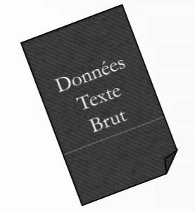

## **~'~Nettoyage des données~'~ :**

```python
def  clean_text(df, text_field):
    df[text_field] = df[text_field].str.lower() # rendre le texte en miniscule
    df[text_field] = df[text_field].apply(lambda elem: re.sub('\s+', ' ', elem)) # supprimer le retour à la ligne
    df[text_field] = df[text_field].apply(lambda elem: re.sub('\S*@\S*\s?', '', elem) )  # supprimer les adresses mail
    df[text_field] = df[text_field].apply(lambda elem: re.sub("\'", "", elem)) # supprimer les quotes



    return df
```

```python
data_clean = clean_text (result, 'descriptions')
data_clean.tail()
```

|  | titre | recruteur | type_contrat | ville | descriptions |
| --- | --- | --- | --- | --- | --- |
| 1095 | Business Analyste (h/f) | Maisons du Monde | job | Nantes (44) | le business analyste est accompagné et évolue ... |
| 1096 | Ingénieur d'affaire H/F | AI & DATA | job | Paris (75) | ai & data recherche un ingénieur daffaires exp... |
| 1097 | Ingénieur Avant-Vente (H/F) | Talentpeople | job | Boulogne-Billancourt (92) | notre client est une entreprise innovante de t... |
| 1098 | Lead Research Engineer | Ava | job | Paris 13e (75) | description de lentreprise we want to radicall... |
| 1099 | Senior Data Scientist (Paris and Berlin) | PriceHubble | job | Paris (75) | pricehubble is a proptech company, set to radi... |

```python
data_clean['langue']=data_clean.descriptions.apply(detect)
```

```python
data_clean.sample(5)
```

|  | titre | recruteur | type_contrat | ville | descriptions | langue |
| --- | --- | --- | --- | --- | --- | --- |
| 219 | Data engineer – LA marketplace référente en Fr... | Konekt | job | Paris 10e (75) | description de lemploi mon client, la marketpl... | fr |
| 423 | Applied Machine Learning Engineer H/F | Quantum Surgical | job | Montpellier (34) | job summary applied machine learning engineer ... | en |
| 1090 | Manager data confirmé (H/F) | PHI RH | job | Paris (75) | phi ntic, division dédiée aux métiers it du ca... | fr |
| 187 | Algorithme IA pour le prétraitement des exigen... | PSAPeugeotCitroen | job | Vélizy-Villacoublay (78) | vous mettrez en pratique vos connaissances en ... | fr |
| 771 | Senior QA Engineer M/F | Shift Technology | job | Paris (75) | shift technology is reinventing insurance clai... | en |

- La bibliothèque python NLTK ( Natural Language Toolkit ) possède des méthodes intégrées pour supprimer lesstopwods.
- Le code ci-dessous l'utilise pour les supprimers.
- éliminer les stopwords pour les 2 langues

```python
#nltk.download('stopwords')
stop_words_en =set(stopwords.words('english'))
stop_words_fr=set(stopwords.words("french"))
```

```python
stop_words =set()
stop_words.update(stop_words_en)
stop_words.update(stop_words_fr)
```

```python
len(stop_words)
```

```
327
```

```python
data_clean['descriptions'] = data_clean['descriptions'].apply(lambda x: ' '.join([word for word in x.split() if word not in (stop_words)]))
data_clean.sample(5)
```

|  | titre | recruteur | type_contrat | ville | descriptions | langue |
| --- | --- | --- | --- | --- | --- | --- |
| 1066 | Ingénieur d'affaire H/F | AI & DATA | job | Paris (75) | & data recherche ingénieur daffaires expérimen... | fr |
| 43 | Data Scientist | Mercedes-Benz Research and Development India P... | job | Bengaluru | job description: data scientist education & tr... | en |
| 746 | Développeur fullstack JAVA H/F | EXTERNATIC | job | Bordeaux (33) | description loffre externatic accompagne aujou... | fr |
| 373 | Data Scientist | Silkhom | job | Paris (75) | sein dune équipe data scientist composée 4 per... | fr |
| 588 | Temporary scientific engineer / Vision, percep... | Inria | job | Sophia Antipolis (06) | descriptif l’offre ci-dessous anglais type con... | en |

```python
data_scrap=data_clean.drop(columns=['langue'])
```

```python
data_pdfword=data
```

```python
data_pdfword.head()
```

|  | titre | recruteur | type_contrat | ville | descriptions |
| --- | --- | --- | --- | --- | --- |
| 0 | data scientist entry level | pathrise recruiting partners | fixed price contract | pathrise | excellent communication skills. ability to un... |
| 1 | data scientists | microsoft | option contracts | redmond wa | some engineering experience and or project cou... |
| 2 | data and applied scientist | microsoft | aleatory contract | redmond wa | experience with eda inference analysis predict... |
| 3 | data scientist | triplebyte | adhesion contract | fully remote | your day to day will include a mix of dataset... |
| 4 | data scientist junior | booz allen hamiltion | unconscionable contract | rome ny | access online and onsite training in data ana... |

```python
data_scrap.head()
```

|  | titre | recruteur | type_contrat | ville | descriptions |
| --- | --- | --- | --- | --- | --- |
| 0 | Responsable junior DATA (H/F) Populaire | GROUPE AFNOR | CDI | Saint-Denis | quelles missions ? rattaché(e) responsable dép... |
| 1 | Life Sciences Market/Strategic Business Analys... | DASSAULT SYSTEMES | CDI | Yvelines | quelles missions ? intégré sein léquipe vp ind... |
| 2 | Data Architecte H/F Soyez le 1er à postuler | No results | CDI | Paris | quelles missions ? qualité data architecte, pr... |
| 3 | Stage - assistant(e) data science, emea h/f Po... | UBISOFT INTERNATIONAL | CDI | Paris | quelles missions ? sein siège emea dubisoft (e... |
| 4 | Assistant(e) Data Scientist H/F Populaire | UBISOFT INTERNATIONAL | Stage | Montreuil | quelles missions ? sein léquipe consumer & mar... |

```python
frames = [data, data_scrap]

all_data = pd.concat(frames)
all_data.shape
```

```
(1268, 5)
```

```python
all_data.sample(5)
```

|  | titre | recruteur | type_contrat | ville | descriptions |
| --- | --- | --- | --- | --- | --- |
| 528 | DIRECTEUR DE PROJET DATA (PARIS/AIX EN PROVENCE) | DigDash | job | Paris (75) | recherchons directeur projet data basé paris a... |
| 301 | Consultant Big Data H/F (Paris) | Keyrus | job | Paris (75) | big data c’est plus qu’un buzzword ? l’interac... |
| 3 | Data scientist f/h | Franprix | job | Vitry-sur-Seine (94) | description lorganisation plus 900 magasins fr... |
| 60 | Data Scientist | Data Semantics | job | Bengaluru | capable creating analytics pipelines pre proce... |
| 492 | Data Product Manager pour une scaleup Martech ... | Data Recrutement | job | Paris (75) | offre publiée 09-05-2020. paris fonction data ... |

## **Phase 2 : labélisation et Classification**

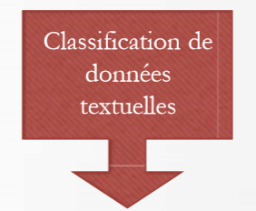

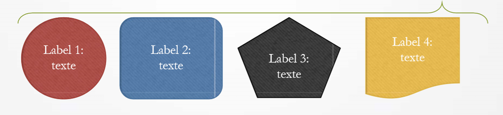

### ---------- 1ére méthode ---------- : --**++Modéle spaCy++**-- modéle NER personalisé

- changement du séparateur des offres ===> "-" entre le parties de chaque offre :

```python
ls=[]
for j in range(0,50):
    ch=''
    for i in v[j] : # liste des offres
        if len(ch)==0:
            ch=ch+i
        else:
            ch=ch+' -'+i
    ls.append(ch)
print(ls)
```

```
['job title: data scientist entry level -  company name: pathrise recruiting partners -  contract type: fixed price contract - location: pathrise - description: excellent communication skills. ability to understand customer needs and provide valuable recommendations. strong python and sql skills. ab…
```

```python
ls[49]
```

```
'job title:  data scientist - company name: amazon -  contract type: fixed price contract - location:washington  - description: advanced knowledge and expertise with data modelling skills. ability to distill informal customer requirements into problem definitions, dealing with ambiguity and competin…
```

- Identifier l'indexe (start , end) de chaque partie (contenu du label) par la fonction **extract_info**)

```python
def find_index(content, text):
    start = content.find(text[:])
    end = len(text) + start
    return start, end

def extract_info(content, t):
    couples = t.split(';')
    info = []
    for couple in couples:
        label, text = couple.split(':')
        start, end = find_index(content, text)
        #start=content.find(text[:50])
        #end=start+len(text)


        pair = (start, end, label)
        #print(text, ' : ', label)
        info.append(pair)
    return info
```

```python
all_offres[49]
```

```
'job title:  data scientist; company name: amazon;  contract type: fixed price contract; location:washington ; description: advanced knowledge and expertise with data modelling skills. ability to distill informal customer requirements into problem definitions, dealing with ambiguity and competing ob…
```

```python
# first try :
extract_info(all_offres[49],all_offres[49])
```

```
[(10, 26, 'job title'),
 (41, 48, ' company name'),
 (65, 86, '  contract type'),
 (97, 108, ' location'),
 (122, 709, ' description')]
```

```python
# all offres :
x=[]
for i in range(0,50):
    #print(i)
    x.append(extract_info(all_offres[i],all_offres[i]))
x
```

```
[[(10, 37, 'job title'),
  (53, 82, '  company name'),
  (99, 120, '  contract type'),
  (53, 62, ' location'),
  (154, 730, ' description')],
 [(10, 26, 'job title'),
  (42, 52, '  company name'),
  (68, 85, ' contract type'),
  (97, 108, '  location'),
  (122, 1098, ' description')],
 [(10, 37, 'job title'),
  (53, 63, '  company name'),
  (79, 97, ' contract type'),
  (109, 120, '  location'),
  (134, 579, ' description')],
 [(10, 25, 'job title'),
  (40, 51, ' company name'),
  (67, 85, ' contract type'),
  (97, 110, '  location'),
  (124, 399, ' description')],
 [(10, 32, 'job title'),
  (47, 68, ' company name'),
  (84, 108, ' contract type'),
  (119, 127, ' location'),
  (141, 542, ' description')],
 [(10, 25, 'job title'),
  (42, 47, '   company name'),
  (63, 97, ' contract type'),
  (108, 122, ' location'),
  (136, 499, ' description')],
 [(10, 25, 'job title'),
  (40, 48, ' company name'),
  (64, 93, ' contract type'),
  (105, 115, '  location'),
  (129, 632, ' description')],
 [(10, 25, 'job title'),
  (40, 59, ' company name'),
  (75, 104, ' contract type'),
  (116, 119, '  location'),
  (133, 1126, ' description')],
```

[output cut: 195 more lines]

```
 [(10, 23, 'job title'),
  (38, 58, ' company name'),
  (74, 95, ' contract type'),
  (106, 113, ' location'),
  (127, 496, ' description')],
 [(10, 32, 'job title'),
  (47, 54, ' company name'),
  (70, 91, ' contract type'),
  (102, 114, ' location'),
  (128, 562, ' description')],
 [(10, 26, 'job title'),
  (41, 48, ' company name'),
  (65, 86, '  contract type'),
  (97, 108, ' location'),
  (122, 709, ' description')]]
```

```python
x[49]
```

```
[(10, 26, 'job title'),
 (41, 48, ' company name'),
 (65, 86, '  contract type'),
 (97, 108, ' location'),
 (122, 709, ' description')]
```

- construction d'une liste des dictionnaires (text | entities ) :

```python
def dict(aa):
    dictionnaire={'entities':aa}
    return dictionnaire
```

```python
# data 0
ll=[]
for i in range(0,50):
    x0=(ls[i],dict(x[i]))
    ll.append(x0)
```

```python
len(ll) # notre liste des dictionnaires
```

```
50
```

```python
ll[49] # dernier élément du liste (dernier dictionnaire)
```

```
('job title:  data scientist - company name: amazon -  contract type: fixed price contract - location:washington  - description: advanced knowledge and expertise with data modelling skills. ability to distill informal customer requirements into problem definitions, dealing with ambiguity and competi…
 {'entities': [(10, 26, 'job title'),
   (41, 48, ' company name'),
   (65, 86, '  contract type'),
   (97, 108, ' location'),
   (122, 709, ' description')]})
```

```python
ll[49][0] # 1er élément du dernier dictionnaire # offre en texte
```

```
'job title:  data scientist - company name: amazon -  contract type: fixed price contract - location:washington  - description: advanced knowledge and expertise with data modelling skills. ability to distill informal customer requirements into problem definitions, dealing with ambiguity and competin…
```

```python
ll[49][1] # 1er élément du dernier dictionnaire # les indexes de l'offre (entities)
```

```
{'entities': [(10, 26, 'job title'),
  (41, 48, ' company name'),
  (65, 86, '  contract type'),
  (97, 108, ' location'),
  (122, 709, ' description')]}
```

### génération des données de formation(entrainement) au format JSON avec chaque ligne contenant le corpus de texte avec les annotations.

[figure not shown]

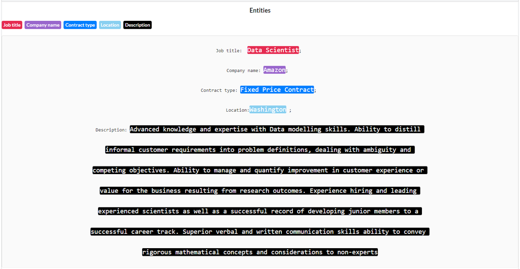

```python
#{}json
#{
#  "content": "Job title:  Data Scientist; \n\nCompany name: Amazon;  \n\nContract type: Fixed Price Contract; \n\nLocation:Washington ; \n\nDescription: Advanced knowledge and expertise with Data modelling skills. Ability to distill \n\ninformal customer requirements into problem definitions, dealing with ambiguity and \n\ncompeting objectives. Ability to manage and quantify improvement in customer experience or \n\nvalue for the business resulting from research outcomes. Experience hiring and leading \n\nexperienced scientists as well as a successful record of developing junior members to a \n\nsuccessful career track. Superior verbal and written communication skills ability to convey \n\nrigorous mathematical concepts and considerations to non-experts",
#  "annotation": [
#    {
#      "label": [
#        "Description"
#      ],
#      "points": [
#        {
#          "start": 131,
#          "end": 728,
#          "text": "Advanced knowledge and expertise with Data modelling skills. Ability to distill \n\ninformal customer requirements into problem definitions, dealing with ambiguity and \n\ncompeting objectives. Ability to manage and quantify improvement in customer experience or \n\nvalue for the business resulting from research outcomes. Experience hiring and leading \n\nexperienced scientists as well as a successful record of developing junior members to a \n\nsuccessful career track. Superior verbal and written communication skills ability to convey \n\nrigorous mathematical concepts and considerations to non-experts"
#        }
#      ]
#    },
#    {
#      "label": [
#        "Location"
#      ],
#      "points": [
#        {
#          "start": 103,
#          "end": 112,
#          "text": "Washington"
#        }
#      ]
#    },
#    {
#      "label": [
#        "Contract type"
#      ],
#      "points": [
#        {
#          "start": 70,
#          "end": 89,
#          "text": "Fixed Price Contract"
#        }
#      ]
#    },
#    {
#      "label": [
#        "Company name"
#      ],
#      "points": [
#        {
#          "start": 44,
#          "end": 49,
#          "text": "Amazon"
#        }
#      ]
#    },
#    {
#      "label": [
#        "Job title"
#      ],
#      "points": [
#        {
#          "start": 12,
#          "end": 25,
#          "text": "Data Scientist"
#        }
#      ]
#    }
#  ],
#  "extras": null,
#  "metadata": {
#    "first_done_at": 1590768560000,
#    "last_updated_at": 1590768560000,
#    "sec_taken": 0,
#    "last_updated_by": "7FJeKu6I0WXoqd3nDSNeFBUTxp72",
#    "status": "done",
#    "evaluation": "NONE"
#  }
#}
```

## Utilisation du modèle spaCy en python pour former un modèle personnalisé:

#### On a entrainé un model qui prend en input les données précédemment extraites des fichiers pdf&word

#### afin qu'il soit capable de tirer des offres les labels ['JOB TITLE', 'COMPANY NAME', 'CONTRACT TYPE', 'LOCATION', 'DESCRIPTION'].

#### Dans cette partie, on a eu recours à la bibliothèque spacy.

#### SpaCy est une bibliothèque python qu'on utilise pour le traitement du langage naturel.

#### Avec le NER( Named Entity Recognition ), on a pu affecter des texts non structurées provenants des offres

#### à leurs rubriques(comme titre, ville ,descriptions, ...)..

```python
############################################  NOTE  ########################################################
#
#           Crée des données de formation NER au format Spacy à partir de JSON téléchargées à partir de Dataturks.
#
#           Génère les données de formation Spacy qui peuvent être utilisées pour la formation Spacy.
#
############################################################################################################
def convert_dataturks_to_spacy(dataturks_JSON_FilePath):
    try:
        training_data = []
        lines=[]
        with open(dataturks_JSON_FilePath, 'r', encoding='utf8', errors='ignore') as f:
            lines = f.readlines()

        for line in lines:
            data = json.loads(line)
            text = data['content']
            entities = []
            for annotation in data['annotation']:
                #only a single point in text annotation.
                point = annotation['points'][0]
                labels = annotation['label']
                # handle both list of labels or a single label.
                if not isinstance(labels, list):
                    labels = [labels]

                for label in labels:
                    #dataturks indices are both inclusive [start, end] but spacy is not [start, end]
                    entities.append((point['start'], point['end'] + 1 ,label))


            training_data.append((text, {"entities" : entities}))

        return training_data
    except Exception as e:
        logging.exception("Unable to process " + dataturks_JSON_FilePath + "\n" + "error = " + str(e))
        return None
```

```python
data=convert_dataturks_to_spacy("D:/Offre1to40.json")
```

```python
nlp = spacy.blank('en') # define the model already empty
def  train_model(train_data):
    if 'ner' not in nlp.pipe_names:
        ner = nlp.create_pipe('ner')
        nlp.add_pipe(ner, last=True)
    for _, annotations in train_data:
        for ent in annotations['entities']:
            ner.add_label(ent[2])


    other_pipes = [pipe for pipe in nlp.pipe_names if pipe != 'ner']
    with nlp.disable_pipes(*other_pipes):  # only train NER
        optimizer = nlp.begin_training()
        for itn in range(1000):
            print("Statring iteration " + str(itn))
            random.shuffle(train_data)
            losses = {}
            index = 0
            for text, annotations in train_data:
                # print(index)
                try:
                    nlp.update(
                        [text],  # batch of texts
                        [annotations],  # batch of annotations
                        drop=0.2,  # dropout - make it harder to memorise data
                        sgd=optimizer,  # callable to update weights
                        losses=losses)

                except Exception as e:
                    pass
                        #print(text)


            print(losses)
```

```python
#train_model(data)
```

[output not shown]

```python
#nlp.to_disk("modele_labelisation")
```

```python
nlp_model= spacy.load('modele_labelisation')
```

```python
# tained data : (test)
doc= nlp_model(data[0][0])
for ent in doc.ents:
    #print(ent)
    print(f'{ent.label_.upper():{80}}-{ent.text}')
```

```
JOB TITLE                                                                       -Data Scientist Entry Level
COMPANY NAME                                                                    -Pathrise Recruiting Partners
CONTRACT TYPE                                                                   -Fixed Price Contract
LOCATION                                                                        -Pathrise
DESCRIPTION                                                                     -Excellent communication skills. Ability to understand customer needs and

provide valuable recommendations. Strong Python and SQL skills. Able to effectively

synthesize visualize and communicate your ideas to others. Familiar with key data

engineering concepts. Experience with data visualization. Being involved with product

discussions about high impact features. Help with various data analysis and modeling

projects. Creating data visualizations for use in both internal and external capacities. Using

data to inform decisions made by product engineering and design teams
```

```python
from spacy import displacy
```

```python
options = {"ents": ['JOB TITLE','COMPANY NAME','CONTRACT TYPE','LOCATION','DESCRIPTION'],
           "colors": {"JOB TITLE": "yellow","COMPANY NAME":"orange","CONTRACT TYPE":"lime","LOCATION":"pink","DESCRIPTION":"violet"}}
displacy.render( nlp_model(data[0][0]), jupyter=True, options=options,style='ent')
```

Job title: Data Scientist Entry Level Job title ;  
Company name: Pathrise Recruiting Partners Company name ;  
Contract type: Fixed Price Contract Contract type ;  
Location: Pathrise Location ;  
Description: Excellent communication skills. Ability to understand customer needs and provide valuable recommendations. Strong Python and SQL skills. Able to effectively synthesize visualize and communicate your ideas to others. Familiar with key data engineering concepts. Experience with data visualization. Being involved with product discussions about high impact features. Help with various data analysis and modeling projects. Creating data visualizations for use in both internal and external capacities. Using data to inform decisions made by product engineering and design teams Description

- Pour valider le model, on va essayer d'extraire les informations des offres provenants d'autres sources(pdf par exemple)
- - source json :

```python
data_test=convert_dataturks_to_spacy("D:/Offre41to50.json")
```

```python
# test data : (model validation)
doc= nlp_model(data_test[4][0])
for ent in doc.ents:
    #print(ent)
    print(f'{ent.label_.upper():{80}}-{ent.text}')
```

```
JOB TITLE                                                                       -Applied Scientist
COMPANY NAME                                                                    -Amazon
CONTRACT TYPE                                                                   -Fixed Price Contract
LOCATION                                                                        -Wanshington
DESCRIPTION                                                                     -Leverage knowledge of statistics and optimization to frame decision-making
problems for understanding seller economics. Translate prototype models to production

quality and large scale software systems. Expertise in causal inference. Experience solving

complex and highly ambiguous business challenges. Proficient in at least one of the common

programming languages
```

- - source pdf :

```python
# model VS pdf file :
import sys, fitz
fname = 'Offre45.pdf'
doc = fitz.open(fname)
text=''
for page in doc:
    text=text+str(page.getText())
#print(text)

tx=" ".join(text.split('/n'))
print(tx)
```

```
Job title: Applied Scientist;
Company name: Amazon;
Contract type: Fixed Price Contract;
Location:Wanshington ;
Description: Leverage knowledge of statistics and optimization to frame decision-making
problems for understanding seller economics. Translate prototype models to production
quality and large scale software systems. Expertise in causal inference. Experience solving
complex and highly ambiguous business challenges. Proficient in at least one of the common
programming languages
```

```python
doc = nlp_model(tx)
for ent in doc.ents:
    print(f'{ent.label_.upper():{30}}- {ent.text}')
```

```
JOB TITLE                     - Applied Scientist
COMPANY NAME                  - Amazon
CONTRACT TYPE                 - Fixed Price Contract
LOCATION                      - Wanshington
DESCRIPTION                   - Leverage knowledge of statistics and optimization to frame decision-making
problems for understanding seller economics. Translate prototype models to production
quality and large scale software systems. Expertise in causal inference. Experience solving
complex and highly ambiguous business challenges. Proficient in at least one of the common
programming languages
```

- le modéle NER devient cappable de découper un Offre d'emploi selon les 5 entités

### ---------- 2éme méthode ---------- : --**++Modéle Machine Learning++**--

```python
dataF=all_data
```

```python
dataF.shape
```

```
(1268, 5)
```

- Construction d'une dataframe constituée de 2 colonnes
- - 1ére colonne: contient les textes correspondants aux differents labels
- - 2éme colonne: represente la variable cible constituée des differents labels ===> **Target**

```python
data_final= pd.DataFrame()
for i in range(dataF.shape[1]):
  var1= dataF[dataF.columns[i]]
  data2= pd.DataFrame(np.array(var1),columns=['sentence'])
  data2["target"]=dataF.columns[i]
  data_final= pd.concat([data2,data_final],axis=0)
  data=data_final
data_final["target"].unique()
```

```
array(['descriptions', 'ville', 'type_contrat', 'recruteur', 'titre'],
      dtype=object)
```

```python
data_final
```

|  | sentence | target |
| --- | --- | --- |
| 0 | excellent communication skills. ability to un... | descriptions |
| 1 | some engineering experience and or project cou... | descriptions |
| 2 | experience with eda inference analysis predict... | descriptions |
| 3 | your day to day will include a mix of dataset... | descriptions |
| 4 | access online and onsite training in data ana... | descriptions |
| ... | ... | ... |
| 1263 | Business Analyste (h/f) | titre |
| 1264 | Ingénieur d'affaire H/F | titre |
| 1265 | Ingénieur Avant-Vente (H/F) | titre |
| 1266 | Lead Research Engineer | titre |
| 1267 | Senior Data Scientist (Paris and Berlin) | titre |

6340 rows × 2 columns

```python
def plot_confusion_matrix(cm, classes,
                          normalize=False,
                          title='Confusion matrix',
                          cmap=plt.cm.Blues):
    """
    This function prints and plots the confusion matrix.
    Normalization can be applied by setting `normalize=True`.
    """
    if normalize:
        cm = cm.astype('float') / cm.sum(axis=1)[:, np.newaxis]
        title = title+' - normalized'

    plt.imshow(cm, interpolation='nearest', cmap=cmap)
    plt.title(title)
    plt.colorbar()
    tick_marks = np.arange(len(classes))
    plt.xticks(tick_marks, classes, rotation=45)
    plt.yticks(tick_marks, classes)

    fmt = '.2f' if normalize else 'd'
    thresh = cm.max() / 2.
    for i, j in itertools.product(range(cm.shape[0]), range(cm.shape[1])):
        plt.text(j, i, format(cm[i, j], fmt),
                 horizontalalignment="center",
                 color="white" if cm[i, j] > thresh else "black")

    plt.tight_layout()
    plt.ylabel('True label')
    plt.xlabel('Predicted label')
```

- Création d'un dictionnaire et le convertir en matrice

```python
X = data_final.drop('target', axis=1)
d = DictVectorizer(sparse=False)
X = d.fit_transform(X.to_dict('records'))
```

```python
y = data_final.target.values
classes = np.unique(y)
classes = classes.tolist()
```

```python
X_train, X_test, y_train, y_test = train_test_split(X, y, test_size = 0.3, random_state=0)
```

- logistic regression :

```python
from sklearn.linear_model import LogisticRegression
logreg = LogisticRegression()
logreg.fit(X_train, y_train)
y_pred_logistic = logreg.predict(X_test)
```

```python
# Validating the algorithm using various Performance metrics
from sklearn.metrics import classification_report
print(classification_report(y_test, y_pred_logistic))
```

```
              precision    recall  f1-score   support

descriptions       0.55      1.00      0.71       383
   recruteur       1.00      0.76      0.86       386
       titre       1.00      0.58      0.73       372
type_contrat       1.00      0.99      0.99       389
       ville       1.00      0.85      0.92       372

    accuracy                           0.84      1902
   macro avg       0.91      0.84      0.84      1902
weighted avg       0.91      0.84      0.85      1902
```

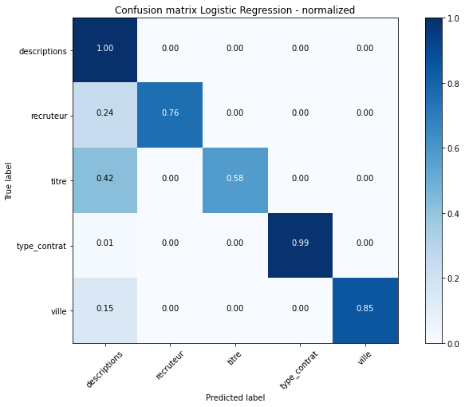

```python
cm_LG_model = confusion_matrix(y_test, y_pred_logistic)
np.set_printoptions(precision=2)
plt.figure(figsize=(10,7));
plot_confusion_matrix(cm_LG_model, classes=logreg.classes_,
                      title='Confusion matrix Logistic Regression', normalize=True);
plt.show()
```

- random forest :

```python
rfcD= RandomForestClassifier()
rfc_modelD = rfcD.fit(X_train, y_train)
y_pred_rfcD = rfcD.predict(X_test)
```

```python
# Validating the algorithm using various Performance metrics
from sklearn.metrics import classification_report
print(classification_report(y_test, y_pred_rfcD))
```

```
              precision    recall  f1-score   support

descriptions       0.57      1.00      0.72       383
   recruteur       1.00      0.76      0.86       386
       titre       1.00      0.57      0.73       372
type_contrat       1.00      1.00      1.00       389
       ville       1.00      0.90      0.94       372

    accuracy                           0.85      1902
   macro avg       0.91      0.85      0.85      1902
weighted avg       0.91      0.85      0.85      1902
```

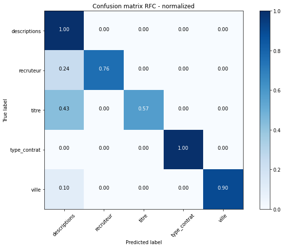

```python
cm_rfc_model = confusion_matrix(y_test, y_pred_rfcD)
np.set_printoptions(precision=2)
plt.figure(figsize=(10,7));
plot_confusion_matrix(cm_rfc_model, classes=rfc_modelD.classes_,
                      title='Confusion matrix RFC', normalize=True);
plt.show()
```

- méthode de classification: Model SGD :

```python
sgd = SGDClassifier()
sgd.partial_fit(X_train, y_train, classes)
```

```
SGDClassifier(alpha=0.0001, average=False, class_weight=None,
              early_stopping=False, epsilon=0.1, eta0=0.0, fit_intercept=True,
              l1_ratio=0.15, learning_rate='optimal', loss='hinge',
              max_iter=1000, n_iter_no_change=5, n_jobs=None, penalty='l2',
              power_t=0.5, random_state=None, shuffle=True, tol=0.001,
              validation_fraction=0.1, verbose=0, warm_start=False)
```

```python
y_pred=sgd.predict(X_test)
```

```python
print(classification_report(y_pred=y_pred, y_true=y_test, labels=classes))
```

```
              precision    recall  f1-score   support

descriptions       1.00      0.39      0.57       383
   recruteur       1.00      0.74      0.85       386
       titre       0.51      1.00      0.67       372
type_contrat       0.99      1.00      1.00       389
       ville       0.97      0.89      0.93       372

    accuracy                           0.80      1902
   macro avg       0.89      0.80      0.80      1902
weighted avg       0.90      0.80      0.80      1902
```

[figure not shown]

```python
cm_sgd_model = confusion_matrix(y_test, y_pred)
np.set_printoptions(precision=2)
plt.figure(figsize=(10,7));
plot_confusion_matrix(cm_sgd_model, classes=sgd.classes_,
                      title='Confusion matrix SGD', normalize=True);
plt.show()
```

- methode de classification: ANN_Perceptron(monocouche)

```python
percept = Perceptron(verbose=30, n_jobs=-1, max_iter=15)
percept.partial_fit(X_train, y_train, classes)
y_pred_per=percept.predict(X_test)
```

```
-- Epoch 1
-- Epoch 1
-- Epoch 1
-- Epoch 1
-- Epoch 1
Norm: 37.67, NNZs: 915, Bias: -1.000000, T: 4438, Avg. loss: 0.084047
Total training time: 0.02 seconds.
Norm: 9.00, NNZs: 51, Bias: -1.000000, T: 4438, Avg. loss: 0.004507
Total training time: 0.02 seconds.
Norm: 39.66, NNZs: 1117, Bias: -1.000000, T: 4438, Avg. loss: 0.108607
Total training time: 0.02 seconds.
Norm: 25.59, NNZs: 406, Bias: -1.000000, T: 4438, Avg. loss: 0.036278
Total training time: 0.02 seconds.
Norm: 41.00, NNZs: 1186, Bias: -1.000000, T: 4438, Avg. loss: 0.114917
Total training time: 0.02 seconds.
```

[output not shown]

```python
print(classification_report(y_pred=y_pred_per, y_true=y_test, labels=classes))
```

```
              precision    recall  f1-score   support

descriptions       0.56      1.00      0.72       383
   recruteur       1.00      0.76      0.86       386
       titre       1.00      0.56      0.72       372
type_contrat       1.00      1.00      1.00       389
       ville       1.00      0.90      0.94       372

    accuracy                           0.84      1902
   macro avg       0.91      0.84      0.85      1902
weighted avg       0.91      0.84      0.85      1902
```

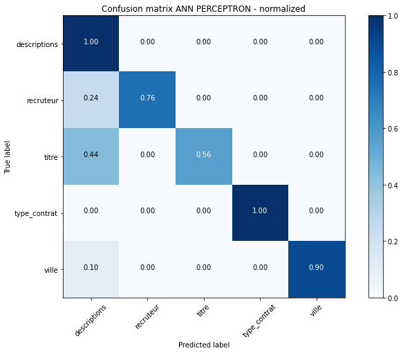

```python
cm_per_model = confusion_matrix(y_test, y_pred_per)
np.set_printoptions(precision=2)
plt.figure(figsize=(10,7));
plot_confusion_matrix(cm_per_model, classes=per.classes_,
                      title='Confusion matrix ANN PERCEPTRON', normalize=True);
plt.show()
```

- On constate que le meilleur score est obtenu par l'algorithme Random Forest
- ===> Prédiction : validation du modéle

```python
ch = {'sentence= paris': 1}
ch = d.transform(ch) # str to vect
print(ch)
rfcD.predict(ch)
```

```
[[0. 0. 0. ... 0. 0. 0.]]
```

```
array(['ville'], dtype=object)
```

```python
ch = {'sentence=amazon': 1}
ch = d.transform(ch)
rfcD.predict(ch)
```

```
array(['recruteur'], dtype=object)
```

```python
ch = {'sentence= fixed price contract': 1}
ch = d.transform(ch)
rfcD.predict(ch)
```

```
array(['type_contrat'], dtype=object)
```

```python
ch = {'sentence=data scientist entry level ': 1}
ch = d.transform(ch)
percept.predict(ch)
```

```
array(['titre'], dtype='<U12')
```

```python
ch = {'sentence= advanced knowledge and expertise with data modelling skills. ability to distill informal customer requirements into problem definitions, dealing with ambiguity and competing objectives. ability to manage and quantify improvement in customer experience or value for the business resulting from research outcomes. experience hiring and leading experienced scientists as well as a successful record of developing junior members to a successful career track. superior verbal and written communication skills ability to convey rigorous mathematical concepts and considerations to non-experts ': 1}
ch = d.transform(ch)
rfcD.predict(ch)
```

```
array(['descriptions'], dtype=object)
```

# **Phase 3 : Réalisation du dictionnaire sémantique et affichage de l'Output Intermédiaire :**

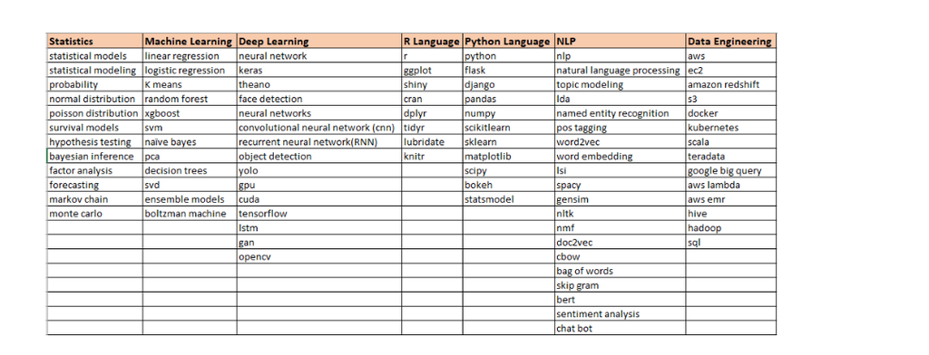

- On a crée un dictionnaire sémantique selon l'image ci-dessus et on a ajouté une colonne "Communication skills"

```python
dataF
```

|  | titre | recruteur | type_contrat | ville | descriptions |
| --- | --- | --- | --- | --- | --- |
| 0 | data scientist entry level | pathrise recruiting partners | fixed price contract | pathrise | excellent communication skills. ability to un... |
| 1 | data scientists | microsoft | option contracts | redmond wa | some engineering experience and or project cou... |
| 2 | data and applied scientist | microsoft | aleatory contract | redmond wa | experience with eda inference analysis predict... |
| 3 | data scientist | triplebyte | adhesion contract | fully remote | your day to day will include a mix of dataset... |
| 4 | data scientist junior | booz allen hamiltion | unconscionable contract | rome ny | access online and onsite training in data ana... |
| ... | ... | ... | ... | ... | ... |
| 1095 | Business Analyste (h/f) | Maisons du Monde | job | Nantes (44) | business analyste accompagné évolue sein d’une... |
| 1096 | Ingénieur d'affaire H/F | AI & DATA | job | Paris (75) | & data recherche ingénieur daffaires expérimen... |
| 1097 | Ingénieur Avant-Vente (H/F) | Talentpeople | job | Boulogne-Billancourt (92) | client entreprise innovante technologies servi... |
| 1098 | Lead Research Engineer | Ava | job | Paris 13e (75) | description lentreprise want radically improve... |
| 1099 | Senior Data Scientist (Paris and Berlin) | PriceHubble | job | Paris (75) | pricehubble proptech company, set radically im... |

1268 rows × 5 columns

```python
data_words=dataF["descriptions"].tolist()
```

```python
data_words;
```

- découpage des offres en phrases

```python
phrase=[]
for j in data_words:
    p=list(j.split(".")) # extraction des phrases selon la ponctuation "."
    phrase.extend(p) # ajouter à la liste
```

```python
len(phrase)
```

```
19555
```

- Prépapation de l'output :

```python
Phrasedata=pd.DataFrame(0,index=phrase,columns=['Statistics','Machine Learning','Deep Learning','R Language','Python Language','NLP','Data Engineering','communication skills'])
```

```python
Phrasedata.head()
```

|  | Statistics | Machine Learning | Deep Learning | R Language | Python Language | NLP | Data Engineering | communication skills |
| --- | --- | --- | --- | --- | --- | --- | --- | --- |
| excellent communication skills | 0 | 0 | 0 | 0 | 0 | 0 | 0 | 0 |
| ability to understand customer needs and provide valuable recommendations | 0 | 0 | 0 | 0 | 0 | 0 | 0 | 0 |
| strong python and sql skills | 0 | 0 | 0 | 0 | 0 | 0 | 0 | 0 |
| able to effectively synthesize visualize and communicate your ideas to others | 0 | 0 | 0 | 0 | 0 | 0 | 0 | 0 |
| familiar with key data engineering concepts | 0 | 0 | 0 | 0 | 0 | 0 | 0 | 0 |

```python
dict=pd.read_csv("dictionnaire.csv",sep=";")
```

```python
dict.head()
```

|  | Statistics | Machine Learning | Deep Learning | R Language | Python Language | NLP | Data Engineering | communication skills |
| --- | --- | --- | --- | --- | --- | --- | --- | --- |
| 0 | statistical models | linear regression | neural network | ggplot | python | nlp | aws | communication |
| 1 | statistical modeling | logistic regression | keras | shiny | flask | natural language processing | ec2 | interaction |
| 2 | probability | K means | theano | cran | django | topic modeling | amazon redshift | excellent oral |
| 3 | normal distribution | random forest | face detection | dplyr | pandas | lda | s3 | Strong verbal |
| 4 | poisson distribution | xgboost | neural networks | tidyr | numpy | named entity recognition | docker | presentation skills |

```python
dictio=dict.fillna("___EMPTY___");
```

```python
dictionnaire=dictio.to_dict('list')
```

```python
dictionnaire.keys()
```

```
dict_keys(['Statistics', 'Machine Learning', 'Deep Learning', 'R Language', 'Python Language', 'NLP', 'Data Engineering', 'communication skills'])
```

```python
dictionnaire.values()
```

```
dict_values([['statistical models', 'statistical modeling', 'probability', 'normal distribution', 'poisson distribution', 'survival models', 'hypothesis testing', 'bayesian inference', 'factor analysis', 'forecasting', 'markov chain', 'monte carlo', 'statistics', 'hypothesis testing', 'stats', 'prob…
```

```python
dictionnaire['NLP']
```

```
['nlp',
 'natural language processing',
 'topic modeling',
 'lda',
 'named entity recognition',
 'pos tagging',
 'word2vec',
 'word embedding',
 'lsi',
 'spacy',
 'genism',
 'nltk',
 'nmf',
 'doc2vec',
 'cbow',
 'bag of words',
 'skip gram',
 'bert',
 'sentiment analysis',
 'chat bot',
 'speech recognition',
 'state to the art',
 'recommender systems ',
 'aws',
 'language processing',
 'state of the art',
 ' ranking & recommendation',
 'state-of-the-art',
 '___EMPTY___',
 '___EMPTY___',
 '___EMPTY___',
 '___EMPTY___',
 '___EMPTY___',
 '___EMPTY___',
 '___EMPTY___',
 '___EMPTY___',
 '___EMPTY___',
 '___EMPTY___',
 '___EMPTY___',
 '___EMPTY___',
 '___EMPTY___',
 '___EMPTY___',
 '___EMPTY___',
 '___EMPTY___',
 '___EMPTY___',
 '___EMPTY___',
 '___EMPTY___',
 '___EMPTY___',
 '___EMPTY___',
 '___EMPTY___',
 '___EMPTY___',
 '___EMPTY___',
 '___EMPTY___',
 '___EMPTY___',
 '___EMPTY___',
 '___EMPTY___',
 '___EMPTY___',
 '___EMPTY___',
 '___EMPTY___',
 '___EMPTY___']
```

- séparation de différentes colonnes (entités) du dictionnaire

```python
stats_words = dictionnaire['Statistics']
ML_words = dictionnaire['Machine Learning']
DL_words = dictionnaire['Deep Learning']
R_words = dictionnaire['R Language']
python_words = dictionnaire['Python Language']
NLP_words = dictionnaire['NLP']
Data_Engineering_words = dictionnaire['Data Engineering']
Communication_Skills = dictionnaire['communication skills']
```

```python
ML_words;
```

```python
test=Phrasedata.to_numpy()
```

```python
test;
```

- filtration des phrases """Phrase Matcher""" similaires : Dans le script ci-dessus:
- - stats_words cherche les expressions - dictionnaire['Statistics']
- - ML_words cherche les expressions - dictionnaire['Machine Learning']
- - DL_words cherche les expressions - dictionnaire['Deep Learning']
- - R_words cherche les expressions - dictionnaire['R Language']
- - python_words cherche les expressions - dictionnaire['Python Language']
- - NLP_words cherche les expressions - dictionnaire['NLP']
- - Data_Engineering_words cherche les expressions - dictionnaire['Data Engineering']
- - Communication_Skills cherche les expressions - dictionnaire['communication skills']

```python
# charge un modèle anglais vierge depuis  :
nlp_blank = spacy.blank('en')
```

```python
liste=[stats_words,ML_words,DL_words,R_words,python_words,NLP_words,Data_Engineering_words,Communication_Skills]
for i in range(len(liste)):
  list_comp=liste[i]
  matcher = PhraseMatcher(nlp_blank.vocab) # # instanciation de l'objet matcher
  key=list(dictionnaire)[i] # définition des pattern
  matcher.add(key, None, *[nlp_blank(entity_i) for entity_i in list_comp]) # ajoutez le motif à l'objet matcher créé précédemment

  for j in range(len(Phrasedata.index)):
    doc = nlp_blank(Phrasedata.index[j])
    matches = matcher(doc) # appeler l'objet matcher l'objet document et il détecte les mots correspondants
    if(len(matches) != 0  ):
      test[j][i]=1
```

```python
PhrasedataF=pd.DataFrame(test,index=phrase,columns=['Statistics','Machine Learning','Deep Learning','R Language','Python Language','NLP','Data Engineering','communication skills'])
```

```python
PhrasedataF.head(5)
```

|  | Statistics | Machine Learning | Deep Learning | R Language | Python Language | NLP | Data Engineering | communication skills |
| --- | --- | --- | --- | --- | --- | --- | --- | --- |
| excellent communication skills | 0 | 0 | 0 | 0 | 0 | 0 | 0 | 1 |
| ability to understand customer needs and provide valuable recommendations | 0 | 0 | 0 | 0 | 0 | 0 | 0 | 1 |
| strong python and sql skills | 0 | 0 | 0 | 0 | 1 | 0 | 1 | 0 |
| able to effectively synthesize visualize and communicate your ideas to others | 0 | 0 | 0 | 0 | 0 | 0 | 0 | 1 |
| familiar with key data engineering concepts | 0 | 0 | 0 | 0 | 0 | 0 | 1 | 0 |

## **Phase 4 : Implication des compétences**

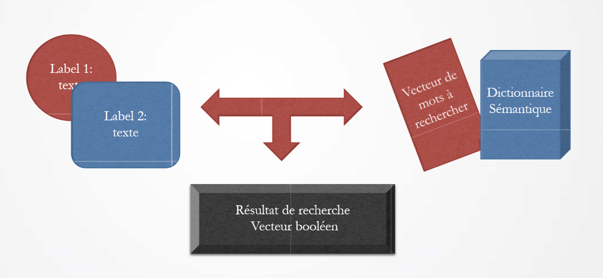

- encodage des modalites de la variable cible("descriptions") puisque chaque phrase peut avoir plusieurs competences a la fois (variable cible multiclasse)

```python
#for k in range(len(test)): # test : matrice de phrases
    #print(test[k]) # test[i] : vecteur de chaque phrase
```

- encodage des phrase selon l'output intermédiare

```python
labelEncode=[]
for k in range(len(test)):
  p="".join(str(test[k]))
  q=p[1:16]
  a=q.replace(" ","")
  #z=int(a,2)
  b=int(a)
  labelEncode.append(b)
```

```python
labelEncode;
```

```python
df= pd.DataFrame(list(zip(phrase, labelEncode)),
               columns =['phrase','target'])
```

```python
X = df['phrase']
y = df['target']
```

- Convertir le text en une matrice de "token counts"

```python
conv = CountVectorizer(lowercase=True)
X = conv.fit_transform(X)
```

- afficher l'occurence des différentes competences

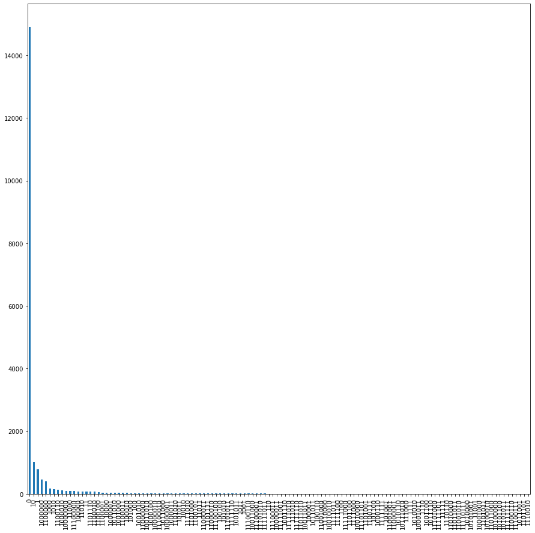

```python
pd.Series(y).value_counts().plot(kind='bar',figsize=(15,15));
```

- corriger le désequilibre entre les classes de la variable cible

```python
oversample = RandomOverSampler()
X_oversample, y_oversample = oversample.fit_resample(X, y)
```

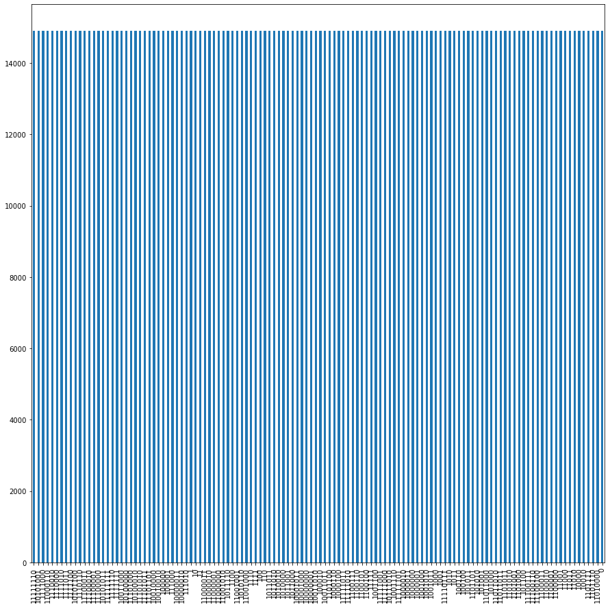

```python
pd.Series(y_oversample).value_counts().plot(kind='bar',figsize=(15,15));
```

```python
X_train, X_test, y_train, y_test = train_test_split(X_oversample, y_oversample, test_size=0.3, random_state=42)
```

- modele SVM Linéaire classifier

```python
# Set dual=False to speed up training, and it's not needed
svc = LinearSVC(random_state=1, dual=False, max_iter=10)
svc.fit(X_train, y_train)
svc.score(X_test,y_test)
y_pred_svc = svc.predict(X_test)
```

```
ConvergenceWarning: Liblinear failed to converge, increase the number of iterations. [_base.py:947]
```

```python
print(f"Accuracy: {svc.score(X_test, y_test) * 100:.3f}%", )
```

```
Accuracy: 99.807%
```

```python
print(metrics.classification_report(y_test, y_pred_svc))
```

```
              precision    recall  f1-score   support

           0       0.93      0.97      0.95      4510
           1       0.97      0.97      0.97      4432
          10       0.98      0.95      0.97      4450
          11       1.00      1.00      1.00      4445
         100       1.00      1.00      1.00      4440
         110       1.00      1.00      1.00      4407
        1000       0.99      0.99      0.99      4528
        1001       1.00      1.00      1.00      4410
        1010       1.00      0.99      1.00      4530
        1011       1.00      1.00      1.00      4418
        1100       1.00      1.00      1.00      4561
        1110       1.00      1.00      1.00      4544
        1111       1.00      1.00      1.00      4525
```

[output cut: 115 more lines]

```python
# pickle
import pickle
pickleModelsvc=[[svc]]
pickle.dump(pickleModel,open('pickleModelsvc.pkl','wb'))
```

- modele Naive Bayes classifier

```python
nbc = MultinomialNB()
nbc.fit(X_train,y_train)
nbc.score(X_test,y_test)
y_pred = nbc.predict(X_test)
```

```python
print(metrics.classification_report(y_test, y_pred))
```

```
              precision    recall  f1-score   support

           0       0.96      0.57      0.71      4510
           1       0.91      0.88      0.89      4432
          10       0.93      0.87      0.90      4450
          11       0.99      1.00      0.99      4445
         100       1.00      0.96      0.98      4440
         110       1.00      1.00      1.00      4407
        1000       0.98      0.86      0.92      4528
        1001       1.00      1.00      1.00      4410
        1010       0.95      0.95      0.95      4530
        1011       1.00      0.83      0.91      4418
        1100       0.97      1.00      0.98      4561
        1110       1.00      1.00      1.00      4544
        1111       1.00      1.00      1.00      4525
```

[output cut: 115 more lines]

```python
# pickle
import pickle
pickleModelnbc=[[nbc]]
pickle.dump(pickleModelnbc,open('pickleModelbayes.pkl','wb'))
```

- Creation d'une fonction qui permet de retourner les competences issues de la variables cible encodée :

```python
def trans(x):
    y=str(x[0]).rjust(8,"0")
    for i in range(len(y)):
        if y[i] == "1":
            print(PhrasedataF.columns[i])
```

- - Evaluation:

```python
ch=["plus 3 years of experience working as a data engineer or similar role bsc in a quantitative discipline handson experience writing productionlevel code in python solid proficiency in sql experience with rdbms and data warehousing experience with version control systems git ability to troubleshoot and resolve data integrity and performance issues proficient in writing technical specifications and documentation excellent communication skills verbal and written experience with aws stack ec2 s3 redshift kinesis glue etc"]
X = conv.transform(ch)
y1=svc.predict(X)
```

```python
trans(y1)
```

```
Machine Learning
Deep Learning
Python Language
NLP
Data Engineering
communication skills
```

```python
#Evaluation:
ch=["develop white papers, blogs, reference implementations, labs, presentations evangelize aws design patterns best practices"]
X2 = conv.transform(ch)
y2=nbc.predict(X2)
```

```python
trans(y2)
```

```
Machine Learning
Deep Learning
NLP
Data Engineering
```

```python
#Evaluation:
ch=["high proficiency in mathematics in particular statistics algorithmic optimization and programming "]
X3 = conv.transform(ch)
y3=nbc.predict(X3)
```

```python
trans(y3)
```

```
Statistics
Machine Learning
Deep Learning
```

```python
#Evaluation:
ch=[" substantial experience working on strategy or fulllife cycle data science with data mining tools like  python  r sas  sql"]
X4 = conv.transform(ch)
y4=svc.predict(X4)
```

```python
trans(y4)
```

```
R Language
Python Language
Data Engineering
```

```python
ch=[" fluent english "]
X5 = conv.transform(ch)
y5=svc.predict(X5)
```

```python
trans(y5)
```

```
communication skills
```

## Bonus :

- *2éme méthode phase 4

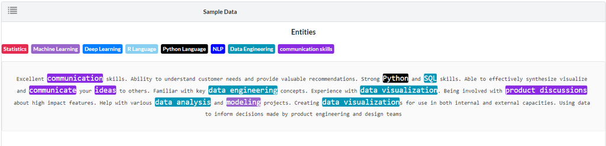

```python
############################################  NOTE  ########################################################
#
#           Crée des données de formation NER au format Spacy à partir de JSON téléchargées à partir de Dataturks.
#
#           Génère les données de formation Spacy qui peuvent être utilisées pour la formation Spacy.
#
############################################################################################################
def convert_dataturks_to_spacy(dataturks_JSON_FilePath):
    try:
        training_data = []
        lines=[]
        with open(dataturks_JSON_FilePath, 'r', encoding='utf8', errors='ignore') as f:
            lines = f.readlines()

        for line in lines:
            data = json.loads(line)
            text = data['content']
            entities = []
            for annotation in data['annotation']:
                #only a single point in text annotation.
                point = annotation['points'][0]
                labels = annotation['label']
                # handle both list of labels or a single label.
                if not isinstance(labels, list):
                    labels = [labels]

                for label in labels:
                    #dataturks indices are both inclusive [start, end] but spacy is not [start, end]
                    entities.append((point['start'], point['end'] + 1 ,label))


            training_data.append((text, {"entities" : entities}))

        return training_data
    except Exception as e:
        logging.exception("Unable to process " + dataturks_JSON_FilePath + "\n" + "error = " + str(e))
        return None
```

```python
data22=convert_dataturks_to_spacy("D:/Description1to40.json")
```

```python
nlp1 = spacy.blank('en') # define the model already empty
def  train_model(train_data):
    if 'ner' not in nlp1.pipe_names:
        ner = nlp1.create_pipe('ner')
        nlp1.add_pipe(ner, last=True)
    for _, annotations in train_data:
        for ent in annotations['entities']:
            ner.add_label(ent[2])


    other_pipes = [pipe for pipe in nlp1.pipe_names if pipe != 'ner']
    with nlp1.disable_pipes(*other_pipes):  # only train NER
        optimizer = nlp1.begin_training()
        for itn in range(100):
            print("Statring iteration " + str(itn))
            random.shuffle(train_data)
            losses = {}
            index = 0
            for text, annotations in train_data:
                # print(index)
                try:
                    nlp1.update(
                        [text],  # batch of texts
                        [annotations],  # batch of annotations
                        drop=0.2,  # dropout - make it harder to memorise data
                        sgd=optimizer,  # callable to update weights
                        losses=losses)

                except Exception as e:
                    pass
                        #print(text)


            print(losses)
```

```python
train_model(data22)
```

[output not shown]

[output cut: 145 more lines]

```
{'ner': 1.449334605320265}
Statring iteration 93
{'ner': 0.9827784118907572}
Statring iteration 94
{'ner': 0.00035518750874006117}
Statring iteration 95
{'ner': 0.0060757025532206625}
Statring iteration 96
{'ner': 0.3733197137696677}
Statring iteration 97
{'ner': 0.878795598706511}
Statring iteration 98
{'ner': 0.4209023828824253}
Statring iteration 99
{'ner': 1.9976959239931735}
```

```python
#nlp1.to_disk("modele_compétance")
```

```python
nlp_model_competance= spacy.load('modele_compétance')
```

```python
# tained data : (test)
doc= nlp_model_competance(data22[0][0])
for ent in doc.ents:
    #print(ent)
    print(f'{ent.label_.upper():{80}}-{ent.text}')
```

```
PYTHON LANGUAGE                                                                 -Python
STATISTICS                                                                      -R
STATISTICS                                                                      -MATLAB
NLP                                                                             -Natural Language Understanding
MACHINE LEARNING                                                                -machine learning
NLP                                                                             -NLU
MACHINE LEARNING                                                                -ML algorithms
MACHINE LEARNING                                                                -linear logistic regression
MACHINE LEARNING                                                                -random forest
MACHINE LEARNING                                                                -boosting GBM
```

```python
from spacy import displacy
options1 = {"ents": ['STATISTICS','MACHINE LEARNING','DEEP LEARNING','R LANGUAGE','PYTHON LANGUAGE','NLP','DATA ENGINEERING','COMMUNICATION SKILLS'],
           "colors": {"STATISTICS": "yellow","MACHINE LEARNING":"CYAN","DEEP LEARNING":"lime","R LANGUAGE":"pink","PYTHON LANGUAGE":"violet","NLP":"TOMATO","DATA ENGINEERING":"DARKKHAKI","COMMUNICATION SKILLS":"SPRINGGREEN"}}
displacy.render( nlp_model_competance(data22[0][0]), jupyter=True, options=options1, style='ent') #"dep"
```

Experience using Python Python Language or other programming or scripting language as well as with R Statistics MATLAB Statistics .  
Experience with Natural Language Understanding NLP concepts. Experience setting up and using robust metrics for machine learning Machine Learning performance evaluation A B testing. Solid understanding of foundational statistics concepts NLU NLP and ML algorithms Machine Learning linear logistic regression Machine Learning random forest Machine Learning boosting GBM Machine Learning NNs

- Pour valider le model, on va essayer d'extraire les informations des offres provenants d'autres sources(pdf par exemple)

```python
# model VS pdf file :
import sys, fitz
fname = 'Description47.pdf'
doc = fitz.open(fname)
text=''
for page in doc:
    text=text+str(page.getText())
#print(text)

tx=" ".join(text.split('/n'))
print(tx)
```

```
Academic or Project Experience with Machine and Deep Learning toolkits such as MXNet or
TensorFlowor  Caffe and PyTorch. Academic Experience with Big Data platforms like
Apache Spark and Hadoop. Academic experience in manipulating and transforming data and
model selection also  model training and cross-validation and deployment at scale. Familiarity
with data processing with Pythonand  R and SQL
```

```python
doc = nlp_model_competance(tx)
for ent in doc.ents:
    print(f'{ent.label_.upper():{30}}- {ent.text}')
```

```
PYTHON LANGUAGE               - Machine
COMMUNICATION SKILLS          - MXNet or
DATA ENGINEERING              - Caffe
DATA ENGINEERING              - PyTorch
DATA ENGINEERING              - Big Data
DATA ENGINEERING              - Spark
DATA ENGINEERING              - Hadoop
MACHINE LEARNING              - model
MACHINE LEARNING              - model
STATISTICS                    - R
DATA ENGINEERING              - SQL
```

```python
# model VS pdf file :
import sys, fitz
fname = 'Description43.pdf'
doc = fitz.open(fname)
text=''
for page in doc:
    text=text+str(page.getText())
#print(text)

tx=" ".join(text.split('/n'))
print(tx)
```

```
Experience with performance tuning Hadoop and Spark implementations. Experience with the
tools Sqoop and  Flume and Kafka and Oozie and Hue and Zookeeper. Experience with SQL
on Hadoop technology  such as Hive or Pig or Impala or Spark SQL or Presto. Developping
software code in one or more programming languages like Java and  JavaScript or Python
```

```python
doc = nlp_model_competance(tx)
for ent in doc.ents:
    print(f'{ent.label_.upper():{30}}- {ent.text}')
```

```
DATA ENGINEERING              - Hadoop
DATA ENGINEERING              - Spark
COMMUNICATION SKILLS          - Kafka
DATA ENGINEERING              - Zookeeper
DATA ENGINEERING              - SQL
DATA ENGINEERING              - Hadoop technology
DATA ENGINEERING              - Hive
DATA ENGINEERING              - Spark
DATA ENGINEERING              - SQL
DATA ENGINEERING              - Presto
PYTHON LANGUAGE               - Python
```

```python
# pickle
import pickle
pickleModelnbc=[[conv]]
pickle.dump(conv,open('conv.pkl','wb'))
```

- *Document (Offre) Similarité :
- - Les documents au contenu similaire ont généralement des vecteurs similaires. Vous pouvez donc trouver des documents similaires en mesurant la similitude entre les vecteurs. Une métrique courante pour cela est la similitude cosinus qui mesure l'angle entre deux vecteurs, a et b.

    $$ \cos \theta = \frac{\mathbf{a}\cdot\mathbf{b}}{\| \mathbf{a} \| \, \| \mathbf{b} \|} $$
- - Il s'agit du produit scalaire de a et b, divisé par les grandeurs de chaque vecteur. La similitude cosinus peut varier entre -1 et 1, correspondant à l'opposé complet de la similitude parfaite, respectivement. Pour le calculer, vous pouvez utiliser le **[metric from scikit-learn](https://scikit-learn.org/stable/modules/generated/sklearn.metrics.pairwise.cosine_similarity.html)** ou écrivez votre propre fonction.

```python
def cosine_similarity(a, b):
    return a.dot(b)/np.sqrt(a.dot(a) * b.dot(b))
```

```python
import en_core_web_sm
nlp = en_core_web_sm.load()
```

```python
a = nlp("substantial experience working on strategy or fulllife cycle data science with data mining tools like  python  r sas  sql").vector
b = nlp("data scientist is required with experince in pyhton r sas sql").vector
```

```python
cosine_similarity(a, b)
```

```
0.73111343
```